# ILAA Tutorial: Body_fat

### 1.7.5 Prediction Using the Observed Features

The predict of the testing set can be done using the `model.matrix()` and the dot product `%*%.`

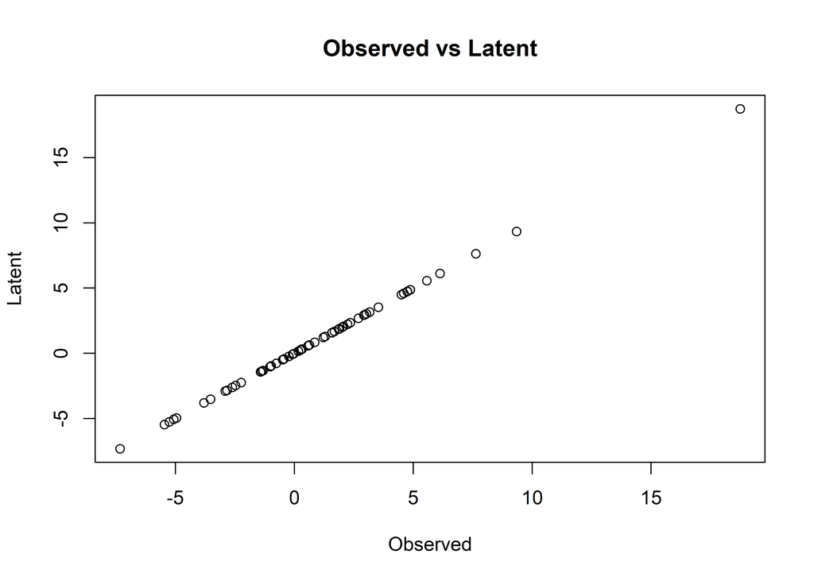

```r
predicOverweightObst <- model.matrix(formula(observedCoef$formula),testingsetBMI) %*% observedCoef$coefficients
#predicOverweightObst <- 1.0/(1.0 + exp(-predicOverweightObst));

plot(predicOverweightObst,predicOverweight,xlab="Observed",ylab="Latent",main="Observed vs Latent")
```

The last plot shows the expected result: both predictions are identical.

### 1.7.6 Comparison to Raw Model

To showcase the advantage of transformed modeling *vs.* raw modeling, here I’ll estimate the logistic model from the observed variables and contrast to the model generated from the transformed space.

The next lines of code compute the logistic model and display its testing performance:

```r
rawmodelOverweight <- LASSO_1SE(Overweight~.,trainingsetBMI,family="binomial")
pander::pander(rawmodelOverweight$coef)
```

| (Intercept) | BodyFat | Chest | Abdomen | Thigh | Ankle | Biceps |
| --- | --- | --- | --- | --- | --- | --- |
| -38.1 | 0.00838 | 0.196 | 0.144 | 0.0226 | 0.0557 | 0.0801 |

```r
rawpredicOverweight <- predict(rawmodelOverweight,testingsetBMI)
pr <- predictionStats_binary(cbind(testingsetBMI$Overweight,rawpredicOverweight),"Overweight")
```

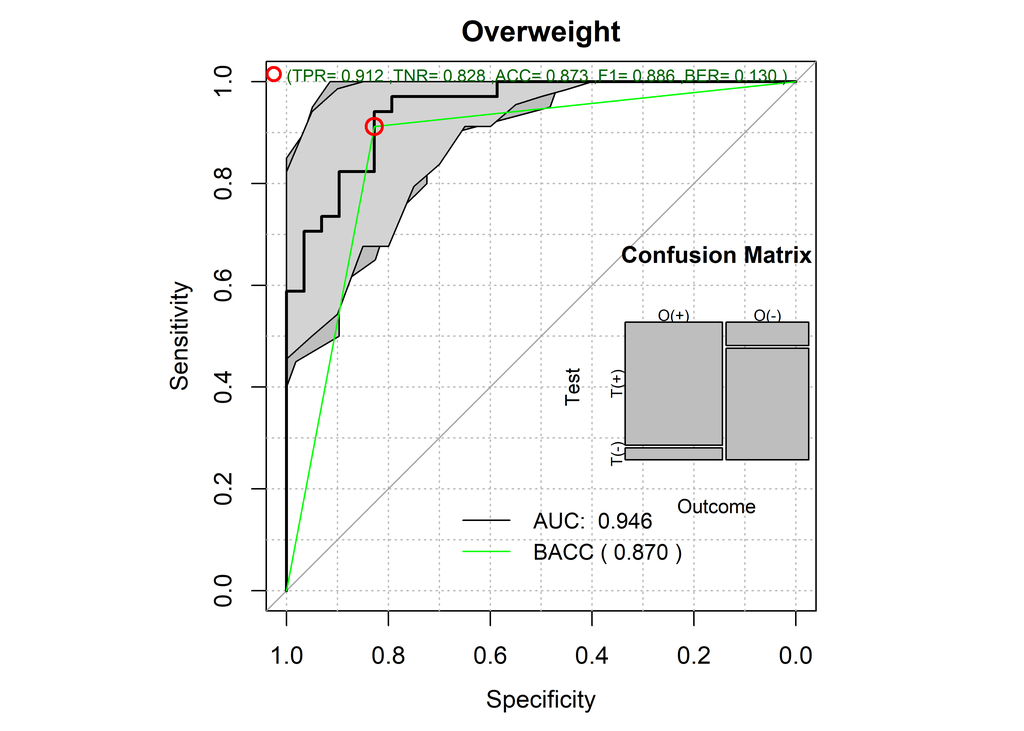

```r
pander::pander(pr$ClassMetrics)
```

- **accci**:

  | 50% | 2.5% | 97.5% |
  | --- | --- | --- |
  | 0.873 | 0.778 | 0.952 |

- **senci**:

  | 50% | 2.5% | 97.5% |
  | --- | --- | --- |
  | 0.872 | 0.776 | 0.949 |

- **aucci**:

  | 50% | 2.5% | 97.5% |
  | --- | --- | --- |
  | 0.872 | 0.776 | 0.949 |

- **berci**:

  | 50% | 2.5% | 97.5% |
  | --- | --- | --- |
  | 0.128 | 0.0509 | 0.224 |

- **preci**:

  | 50% | 2.5% | 97.5% |
  | --- | --- | --- |
  | 0.875 | 0.788 | 0.952 |

- **F1ci**:

  | 50% | 2.5% | 97.5% |
  | --- | --- | --- |
  | 0.871 | 0.776 | 0.951 |

### 1.7.7 Comparing the Feature Significance on the Model

```r
par(mfrow=c(2,2),cex=0.5)

rawlm <- lm(Overweight~.,trainingsetBMI[,c("Overweight",names(rawmodelOverweight$coef)[-1])])
pander::pander(rawlm,add.significance.stars=TRUE)
```

Fitting linear model: Overweight ~ .

|  | Estimate | Std. Error | t value | Pr(>\|t\|) |  |
| --- | --- | --- | --- | --- | --- |
| **(Intercept)** | -3.96182 | 0.40972 | -9.669 | 4.30e-18 | * * * |
| **BodyFat** | 0.00588 | 0.00492 | 1.194 | 2.34e-01 |  |
| **Chest** | 0.01521 | 0.00781 | 1.947 | 5.31e-02 |  |
| **Abdomen** | 0.01486 | 0.00743 | 2.000 | 4.70e-02 | * |
| **Thigh** | -0.00120 | 0.00807 | -0.149 | 8.82e-01 |  |
| **Ankle** | 0.02388 | 0.01761 | 1.356 | 1.77e-01 |  |
| **Biceps** | 0.03003 | 0.01229 | 2.444 | 1.55e-02 | * |

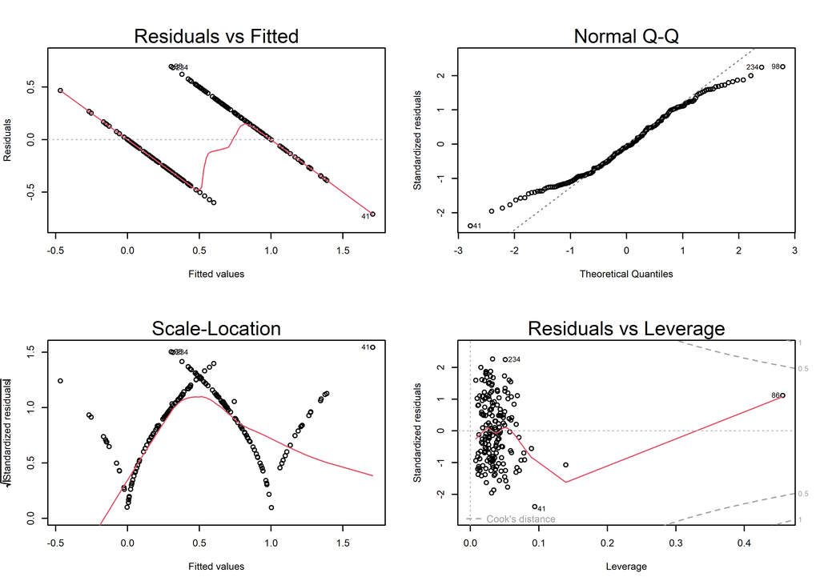

```r
plot(rawlm)
```

```r
par(mfrow=c(2,2),cex=0.5)
Delm <- lm(Overweight~.,BMI_Decorrelated_test[,c("Overweight",names(modelOverweight$coef)[-1])])
pander::pander(Delm,add.significance.stars=TRUE)
```

Fitting linear model: Overweight ~ .

|  | Estimate | Std. Error | t value | Pr(>\|t\|) |  |
| --- | --- | --- | --- | --- | --- |
| **(Intercept)** | -1.89368 | 0.85231 | -2.222 | 3.02e-02 | * |
| **La_BodyFat** | 0.00688 | 0.00908 | 0.758 | 4.51e-01 |  |
| **La_Chest** | 0.03938 | 0.00968 | 4.069 | 1.44e-04 | * * * |
| **La_Abdomen** | 0.03020 | 0.01885 | 1.602 | 1.15e-01 |  |
| **Hip** | 0.03490 | 0.00680 | 5.131 | 3.49e-06 | * * * |

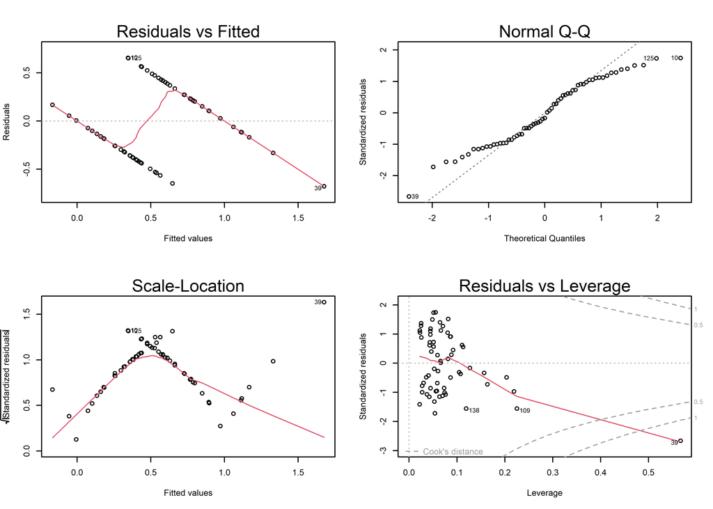

```r
plot(Delm)
```

## 1.8 Conclusion

ILAA is an unsupervised computer-based approach for the estimation of linear transformation matrices that trasforms datasets into a new latent-based space with a degree of user-controlled correlation. This report presented a clear example of the use of ILAA as well as all the functions to estimate, predict and inspect the transformations with practical applications in supervised learning of regression and logistic models.